# Jupyter Notebook: Architecture and Usage Practice

Nikolay Karelin, PhD

Lead Developer, CIB Software

# CIB Software

[figure not shown]

CIB software is a Belarusian R&D and representative center of CIB group of companies (Germany). Founded in 1989 in Munich, CIB group is involved in manufacturing of software products and providing high-end digital solutions in document management, finance, publishing, and other areas. 180 employees in 6 offices serve more than 300 B2B and 160.000 B2C customers across Europe.

Machine Learning and Python are used at CIB for advanced document processing and analysis, including image processing, NLP and Deep Learning algorithms.

The talk is about the main principles of Jupyter notebooks and how these principles influence the practice of Jupyter use. The aim of the presentation is to give some understanding on how the different features of the Jupyter platform are related and how use the Jupyter efficiently in everyday data processing tasks.

## Overview

- Introduction
  - Why Jupyter?
  - A bit of history
  - Example
  - Python scientific stack
  - Documentation
- Architecture
- Live document
- Data science front-end

http://jupyter.org/index.html

[figure not shown]

http://jupyter.org/index.html

> The Jupyter Notebook is a web application that allows you to create and share documents that contain live code, equations, visualizations and explanatory text. Uses include: data cleaning and transformation, numerical simulation, statistical modeling, machine learning and much more.

https://talkpython.fm/episodes/show/44/project-jupyter-and-ipython

> - Interactive computing
> - Reproducible research
> - Software-based communication

# Usage

`pip install jupyter`

Anaconda: built-in

`jupyter notebook --port 80`

# Simplest example

Let's plot the function

$$y = \frac{sin(\pi x)}{\pi x}$$

for $x$ in $[-2.0, 2.0]$

```python
import numpy as np
# import matplotlib as mpl
from matplotlib import pyplot as plt

plt.rcParams['figure.figsize'] = (10,10)

%matplotlib inline
```

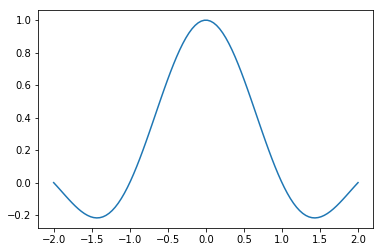

```python
x = np.linspace(-2.0, 2.0, 100)
y = np.sinc(x)

plt.plot(x, y)
```

# Try

[figure not shown]

https://try.jupyter.org/

# History

http://blog.fperez.org/2012/01/ipython-notebook-historical.html

- 2001 - IPython 0.0.1, https://gist.github.com/fperez/1579699
- 2006-2007 - First notebook attempt (similar to Sage)
- 2011 - Qt console, Kernel/UI separation
- December 2011 - IPython Notebook was added to IPython in the 0.12 release
- 2014 - Project Jupyter (big split: **Ju**lia, **Pyt**hon, **R**)

> As of IPython 4.0, the language-agnostic parts of the project: the notebook format, message protocol, qtconsole, notebook web application, etc. have moved to new projects under the name Jupyter. IPython itself is focused on interactive Python, part of which is providing a Python kernel for Jupyter.

# IPython/Jupyter idea

- Literate computing
- Reproducible research
- Notebook as Excel replacement

http://blog.fperez.org/2013/04/literate-computing-and-computational.html

## Influenced by:

- Wolfram Mathematica
- Maple
- MathCad
- Sage

# Overview

- Introduction
- **Architecture**
  - Main components
  - Client-server by default
  - Limitations and security
  - Available languages
- Live document
- Data science front-end

# Architecture

[figure not shown]

https://jupyter.readthedocs.io/en/latest/architecture/how_jupyter_ipython_work.html

# Structure

- IPython
- ØMQ, http://zeromq.org/
- Tornado, http://www.tornadoweb.org
- jQuery, https://jquery.com/
- Bootstrap, http://getbootstrap.com/
- MathJax, https://www.mathjax.org/
- `.ipynb`, JSON format

# Features

- Languates beyond Python
  - https://github.com/ipython/ipython/wiki/IPython%20kernels%20for%20other%20languages
  - Protocol implementation or wrapper
  - How widespread???
- UI for free
- Not only dynamic languages
- Client-server
- Parallelization / clustering

# Input/Output History

- `_i`, `_ii`, `_iii`: store previous, next previous and next-next previous inputs
- `In`, `_ih`: a list of all inputs
- `_` (a single underscore): stores previous output, like Python’s default interpreter
- `__` (two underscores): next previous
- `___` (three underscores): next-next previous
- `_21`: 21st output
- `Out`, or `_oh`: list of all outputs

http://ipython.readthedocs.io/en/stable/interactive/reference.html

## What the caveat???

```python
print(bytes(In[1], "utf-8").decode('unicode_escape'))
```

```
import numpy as np
# import matplotlib as mpl
from matplotlib import pyplot as plt

plt.rcParams['figure.figsize'] = (10,10)

get_ipython().magic('matplotlib inline')
```

```python
import sys

sys.getsizeof(Out[2])
```

```
96
```

# Books

| Learning IPython for Interactive ... | IPython Interactive Computing ... Cookbook | Python for Data Analysis |
| --- | --- | --- |

https://ipython.org/books.html

| Mastering IPython 4.0 | Learning Jupyter |
| --- | --- |

https://ipython.org/books.html

# Docs, intro

- https://jupyter.readthedocs.io/
  - Work in progress
  - Many parts from IPython
- Project docs
  - http://jupyter-notebook.readthedocs.io/
  - http://jupyter_console.readthedocs.io/
  - https://qtconsole.readthedocs.io/
  - https://ipywidgets.readthedocs.io/
  - https://ipyparallel.readthedocs.io/
  - ...
- http://arogozhnikov.github.io/2016/09/10/jupyter-features.html

# Overview

- Introduction
- Architecture
- **Live document**
  - Document and code
  - Use of closed libraries
  - Version control
  - `nbviever` / `nbconvert`
- Data science front-end

# Team work and information exchange

- Code
- Explanations
  - Why?
  - How?
  - References

# Notebook format

- JSON-based
- VCS-compatible
- Outputs!
- Team work for
  - Special hardware (GPU)
  - Proprietary/specialized software
- VCS issues (encoded blobs)
  - `nbdime` package

# nbviewer

[figure not shown]

https://nbviewer.jupyter.org/

# nbconvert

- Output formats
  - HTML, RST, MarkDown
  - Slideshow (`reveal.js`)
  - `.py` file
  - LaTeX, PDF, ...
- Use-cases
  - From exploration to production
  - Presentations
  - Books, papers, ...

# Slides

**Idea:** Notebooks are just JSON files

- `jupyter nbconvert "From IPython to Jupyter.ipynb" --to slides --post serve`
- Special cell types
- `reveal.js`, https://github.com/hakimel/reveal.js/
- Example: http://www.slideviper.oquanta.info/tutorial/slideshow_tutorial_slides.html
- Intro: http://www.damian.oquanta.info/posts/make-your-slides-with-ipython.html
- Custom templates: http://www.damian.oquanta.info/posts/customizing-your-ipython-slides.html
- Templating: http://www.damian.oquanta.info/posts/change-the-ipython-slides-defaults-with-an-ipython-config-file.html
- `nbconvert` doc: http://nbconvert.readthedocs.io/en/latest/usage.html

# Overview

- Introduction
- Architecture
- Live document
- **Data science front-end**
  - Extensibility
  - `ipywidgets`
  - Interactive plotting
  - Mapping

# Final notes

[figure not shown]

https://en.unesco.org/news/2017-nobel-prize-physics-recognises-observation-gravitational-waves

https://losc.ligo.org/tutorials/

[figure not shown]

- https://losc.ligo.org/tutorials/
- https://notebooks.azure.com/losc/libraries/tutorials/html/LOSC_Event_tutorial.ipynb

# Thank you

Nikolay Karelin

skype:nkarelin

Slides: https://github.com/karelin/meetup_jupyter